# Instructor Ratings with Multiple Linear Regression

# Executive Summary

**Objectives & Problem Statement**

This analysis investigates the primary factors influencing student evaluations of their instructors, aiming to isolate which attributes, course characteristics, and demographic variables drive perceived quality. By using rigorous statistical modeling, this project quantifies these relationships to separate meaningful indications from noise and evaluate potential structural inequalities in rating metrics.

**Data & Methodology**

The analysis was conducted using a comprehensive dataset tracking instructor ratings alongside a diverse group of course and rater metrics. The analytical workflow, built entirely within R and the Tidyverse ecosystem involved:

- **Exploratory Data Analysis (EDA):**Assessing multicollinearity through correlation matrices to understand overlapping variance among rating metrics.
- **Model Progression:**Fitting an initial 16-variable global additive regression model, executing stepwise variable selection, introducing complex interaction terms, and finalizing a variance-stabilizing response transformation.
- **Diagnostic Validation:**Testing Gauss-Markov assumptions using both visual and statistical diagnostics. This included analyzing **Residuals vs Fitted plots** to check for constant variance (homoscedasticity) and **Normal Q-Q plots** to evaluate normality, backed by Breusch-Pagan and Shapiro-Wilk for residual normality to ensure inferential validity.

# Data Preparation & Setup

### Libraries

```r
#Core data manipulation and visualization (loads dplyr, ggplot2, tidyr, etc.)
library(tidyverse)

#Modeling, diagnostics, and tidying
library(car)
library(MASS)
library(faraway)
library(lmtest)
library(broom)

#Formatting and reporting
library(knitr)
library(kableExtra)
library(bookdown)
library(ggcorrplot)
```

### Helper Functions

```r
#Reusable function to build standard vertical regression statistics tables
create_model_summary <- function(model_object, table_caption) {
  g_stats <- glance(model_object)

  stat_df <- data.frame(
    " " = c("F - Statistic",
            "Residual Standard Error",
            "Multiple R - Squared",
            "Adjusted R - Squared"),
    "Value" = c(
      round(g_stats$statistic, 4),
      round(g_stats$sigma, 4),
      round(g_stats$r.squared, 4),
      round(g_stats$adj.r.squared, 4)
    ),
    "DF" = c(
      paste0(g_stats$df - 1, " and ", g_stats$df.residual),
      as.character(g_stats$df.residual),
      NA,
      NA
    ),
    "Pr(>|t|)" = c(
      format.pval(g_stats$p.value, digits = 4),
      NA,
      NA,
      NA
    ),
    check.names = FALSE
  )

  options(knitr.kable.NA = ' ')

 kable(
    stat_df,
    caption = table_caption,
    align = c("l", "c", "c", "c"),
    format = "html"
  ) |>
    kable_styling(
      bootstrap_options = c("striped", "hover", "condensed"),
      full_width = FALSE,
      position = "center"
    )
}
```

### Load Data

```r
library(alr4)
data("Rateprof")
```

# Exploratory Data Analysis

### Preliminary Exploratory Analysis: Pairs Plot

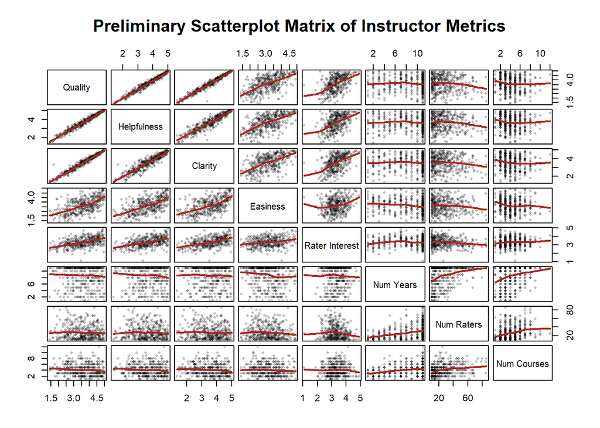

```r
#Define a smooth panel function to add trend lines
panel.smooth.custom <- function (x, y, ...) {
    points(x, y, col = rgb(0, 0, 0, 0.25), pch = 16, cex = 0.6) # Semi-transparent points
    lines(lowess(x, y), col = "firebrick", lwd = 2)             # Smooth red trend line
}

#Run the pairs plot using your dataset columns
pairs(Rateprof[, c("quality", "helpfulness", "clarity", "easiness",
                          "raterInterest", "numYears", "numRaters", "numCourses")],
      lower.panel = panel.smooth.custom,   # Applies the points and lines to the lower triangle
      upper.panel = panel.smooth.custom,   # Applies to the upper triangle (or set to NULL to reduce clutter)
      main = "Preliminary Scatterplot Matrix of Instructor Metrics",
      gap = 0.4,                           # Tightens the spacing between panels
      labels = c("Quality", "Helpfulness", "Clarity", "Easiness",
                 "Rater Interest", "Num Years", "Num Raters", "Num Courses"))
```

### Correlation Matrix

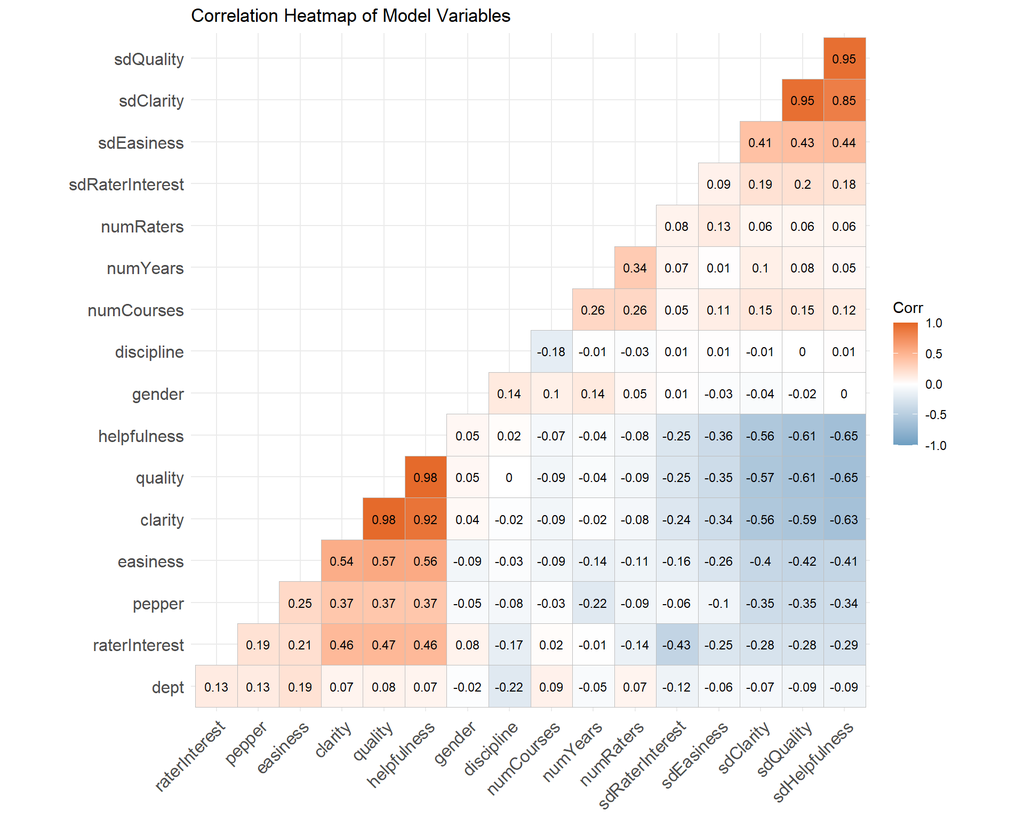

```r
#Create data frame to convert variables to numeric to use for cor()
num_df <- Rateprof
#Convert to numeric
num_df <- num_df %>%
  mutate(across(where(is.factor), as.numeric))

#Compute correlation matrix
cor_matrix <- cor(num_df)

#Plot an elegant heatmap showing only the lower triangle
ggcorrplot(cor_matrix,
           hc.order = TRUE,
           type = "lower",
           lab = TRUE,           # Adds text labels inside squares
           lab_size = 3,         # Perfect size for many variables
           method = "square",
           colors = c("#6D9EC1", "white", "#E46726"), # Clean professional gradient
           title = "Correlation Heatmap of Model Variables",
           ggtheme = theme_minimal())
```

```r
#Compute correlation matrix
cor_tb <- (round(cor(num_df), 2))

options(knitr.kable.NA = ' ')
tb1_cor <- kable(
  cor_tb,
  caption = "Correlation Matrix Table",
  align = c("l", "c", "c", "c"),
  digits = 4,
  format = "html",
  booktabs = TRUE
) %>%
  kable_styling(latex_options = "scale_down")

tb1_cor
```

Correlation Matrix Table

|  | gender | numYears | numRaters | numCourses | pepper | discipline | dept | quality | helpfulness | clarity | easiness | raterInterest | sdQuality | sdHelpfulness | sdClarity | sdEasiness | sdRaterInterest |
| --- | --- | --- | --- | --- | --- | --- | --- | --- | --- | --- | --- | --- | --- | --- | --- | --- | --- |
| gender | 1.00 | 0.14 | 0.05 | 0.10 | -0.05 | 0.14 | -0.02 | 0.05 | 0.05 | 0.04 | -0.09 | 0.08 | -0.02 | 0.00 | -0.04 | -0.03 | 0.01 |
| numYears | 0.14 | 1.00 | 0.34 | 0.26 | -0.22 | -0.01 | -0.05 | -0.04 | -0.04 | -0.02 | -0.14 | -0.01 | 0.08 | 0.05 | 0.10 | 0.01 | 0.07 |
| numRaters | 0.05 | 0.34 | 1.00 | 0.26 | -0.09 | -0.03 | 0.07 | -0.09 | -0.08 | -0.08 | -0.11 | -0.14 | 0.06 | 0.06 | 0.06 | 0.13 | 0.08 |
| numCourses | 0.10 | 0.26 | 0.26 | 1.00 | -0.03 | -0.18 | 0.09 | -0.09 | -0.07 | -0.09 | -0.09 | 0.02 | 0.15 | 0.12 | 0.15 | 0.11 | 0.05 |
| pepper | -0.05 | -0.22 | -0.09 | -0.03 | 1.00 | -0.08 | 0.13 | 0.37 | 0.37 | 0.37 | 0.25 | 0.19 | -0.35 | -0.34 | -0.35 | -0.10 | -0.06 |
| discipline | 0.14 | -0.01 | -0.03 | -0.18 | -0.08 | 1.00 | -0.22 | 0.00 | 0.02 | -0.02 | -0.03 | -0.17 | 0.00 | 0.01 | -0.01 | 0.01 | 0.01 |
| dept | -0.02 | -0.05 | 0.07 | 0.09 | 0.13 | -0.22 | 1.00 | 0.08 | 0.07 | 0.07 | 0.19 | 0.13 | -0.09 | -0.09 | -0.07 | -0.06 | -0.12 |
| quality | 0.05 | -0.04 | -0.09 | -0.09 | 0.37 | 0.00 | 0.08 | 1.00 | 0.98 | 0.98 | 0.57 | 0.47 | -0.61 | -0.65 | -0.57 | -0.35 | -0.25 |
| helpfulness | 0.05 | -0.04 | -0.08 | -0.07 | 0.37 | 0.02 | 0.07 | 0.98 | 1.00 | 0.92 | 0.56 | 0.46 | -0.61 | -0.65 | -0.56 | -0.36 | -0.25 |
| clarity | 0.04 | -0.02 | -0.08 | -0.09 | 0.37 | -0.02 | 0.07 | 0.98 | 0.92 | 1.00 | 0.54 | 0.46 | -0.59 | -0.63 | -0.56 | -0.34 | -0.24 |
| easiness | -0.09 | -0.14 | -0.11 | -0.09 | 0.25 | -0.03 | 0.19 | 0.57 | 0.56 | 0.54 | 1.00 | 0.21 | -0.42 | -0.41 | -0.40 | -0.26 | -0.16 |
| raterInterest | 0.08 | -0.01 | -0.14 | 0.02 | 0.19 | -0.17 | 0.13 | 0.47 | 0.46 | 0.46 | 0.21 | 1.00 | -0.28 | -0.29 | -0.28 | -0.25 | -0.43 |
| sdQuality | -0.02 | 0.08 | 0.06 | 0.15 | -0.35 | 0.00 | -0.09 | -0.61 | -0.61 | -0.59 | -0.42 | -0.28 | 1.00 | 0.95 | 0.95 | 0.43 | 0.20 |
| sdHelpfulness | 0.00 | 0.05 | 0.06 | 0.12 | -0.34 | 0.01 | -0.09 | -0.65 | -0.65 | -0.63 | -0.41 | -0.29 | 0.95 | 1.00 | 0.85 | 0.44 | 0.18 |
| sdClarity | -0.04 | 0.10 | 0.06 | 0.15 | -0.35 | -0.01 | -0.07 | -0.57 | -0.56 | -0.56 | -0.40 | -0.28 | 0.95 | 0.85 | 1.00 | 0.41 | 0.19 |
| sdEasiness | -0.03 | 0.01 | 0.13 | 0.11 | -0.10 | 0.01 | -0.06 | -0.35 | -0.36 | -0.34 | -0.26 | -0.25 | 0.43 | 0.44 | 0.41 | 1.00 | 0.09 |
| sdRaterInterest | 0.01 | 0.07 | 0.08 | 0.05 | -0.06 | 0.01 | -0.12 | -0.25 | -0.25 | -0.24 | -0.16 | -0.43 | 0.20 | 0.18 | 0.19 | 0.09 | 1.00 |

# Methodology

### Population Regression Equation

To investigate the driving factors of instructor ratings, we first specify the global Population Regression Equation. This theoretical model incorporates all 16 main-effect predictors before any variable selection or interaction transformations are applied:

$$\begin{aligned}
\widehat{\text{quality}} ={} & \hat{\beta}_0 +
\hat{\beta}_1\text{gender} + \hat{\beta}_2\text{numYears} +
\hat{\beta}_3\text{numRaters} + \hat{\beta}_4\text{numCourses} \\
& + \hat{\beta}_5\text{pepper} + \hat{\beta}_6\text{discipline} +
\hat{\beta}_7\text{dept} + \hat{\beta}_8\text{helpfulness} \\
& + \hat{\beta}_9\text{clarity} + \hat{\beta}_{10}\text{easiness} +
\hat{\beta}_{11}\text{raterInterest} + \hat{\beta}_{12}\text{sdQuality}
\\
& + \hat{\beta}_{13}\text{sdHelpfulness} +
\hat{\beta}_{14}\text{sdClarity} + \hat{\beta}_{15}\text{sdEasiness} +
\hat{\beta}_{16}\text{sdRaterInterest}
\end{aligned}$$

Using our sample dataset, we will fit this model via Ordinary Least Squares (OLS) to derive our Estimated Regression Equation, allowing us to analyze individual predictor significance and test for Gauss-Markov assumptions.

## Model Fitting

### Fit the Model: Full Additive Model

```r
#Full additive model
lm1 <- lm(quality ~ gender + numYears + numRaters
    + numCourses + pepper + discipline + dept
    + helpfulness + clarity + easiness
    + raterInterest + sdQuality + sdHelpfulness
    + sdClarity + sdEasiness
    + sdRaterInterest, Rateprof)
```

Summary output for full additive model.

```r
#Model I Summary Statistics Table
#For Model I
create_model_summary(lm1, "Regression Statistics: Full Additive Model I")
```

Regression Statistics: Full Additive Model I

|  | Value | DF | Pr(>\|t\|) |
| --- | --- | --- | --- |
| F - Statistic | 1893.8518 | 60 and 304 | < 2.2e-16 |
| Residual Standard Error | 0.0470 | 304 |  |
| Multiple R - Squared | 0.9974 |  |  |
| Adjusted R - Squared | 0.9968 |  |  |

### Check Assumptions

Constant Variance and Normality

A residuals versus fitted values plot with Breusch - Pagan test. And a normal Q - Q plot with Shapiro - Wilk test.

```r
#Residuals vs Fitted
plot(lm1, which = 1, col = rgb(0, 0, 0, 0.6), pch = 16)

#Normal Q-Q Plot
plot(lm1, which = 2, col = rgb(0, 0, 0, 0.6), pch = 16)

save.image()

#Breusch- Pagan Test
bp1 <- bptest(lm1)
bp1
```

```
##
##  studentized Breusch-Pagan test
##
## data:  lm1
## BP = 65.801, df = 61, p-value = 0.3143
```

```r
#Shapiro - Wilk Test
shap1 <- shapiro.test(resid(lm1))
shap1
```

```
##
##  Shapiro-Wilk normality test
##
## data:  resid(lm1)
## W = 0.36996, p-value < 2.2e-16
```

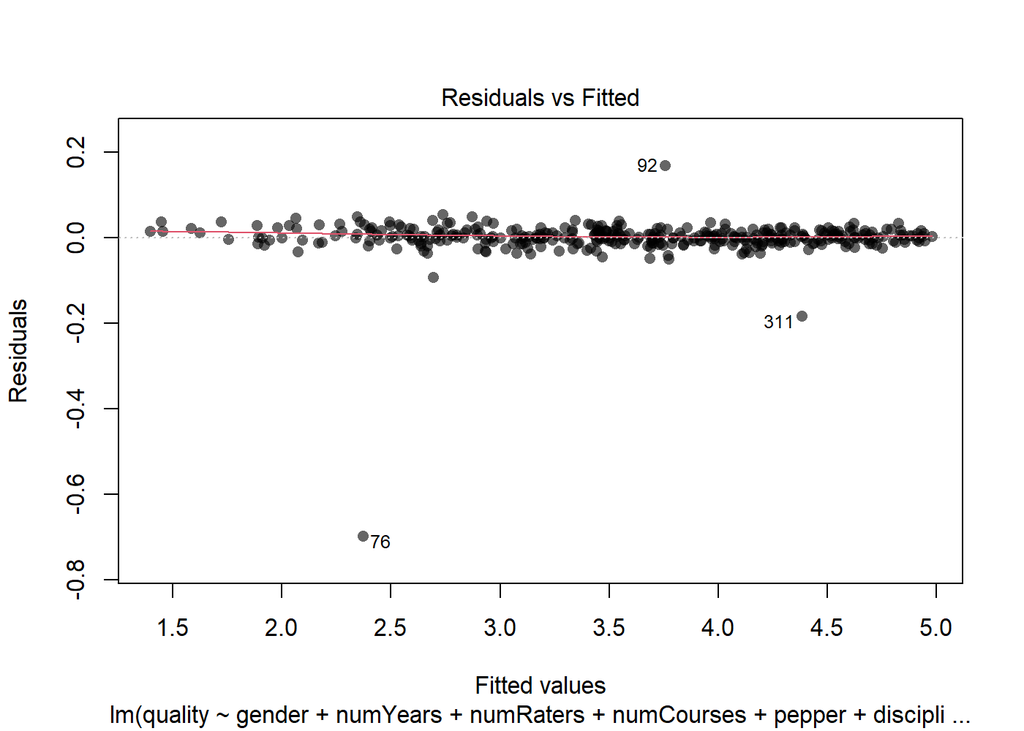

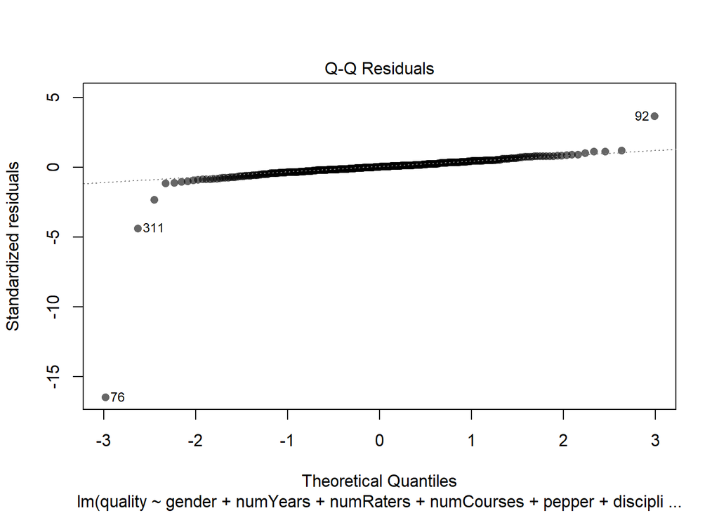

Diagnostic Plots for the Full Additive Model I

### Fit the model: Use the stepwise function on the full additive model.

```r
#Recall:
lm1 <- lm(quality ~ gender + numYears + numRaters
    + numCourses + pepper + discipline + dept +
    + helpfulness + clarity + easiness +  raterInterest
    + sdQuality + sdHelpfulness + sdClarity + sdEasiness
    + sdRaterInterest, Rateprof)

#Step() with full additive model
lm2 <- step(lm1, trace = 0)
```

Summary output for the stepwise model from the full additive model.

```r
#Model II Summary Statistics
create_model_summary(lm2, "Regression Statistics: Stepwise Additive Model II")
```

Regression Statistics: Stepwise Additive Model II

|  | Value | DF | Pr(>\|t\|) |
| --- | --- | --- | --- |
| F - Statistic | 25900.9196 | 4 and 360 | < 2.2e-16 |
| Residual Standard Error | 0.0444 | 360 |  |
| Multiple R - Squared | 0.9972 |  |  |
| Adjusted R - Squared | 0.9972 |  |  |

### Check Assumptions

Constant Variance and Normality

A residuals versus fitted values plot with Breusch - Pagan test. And a normal Q - Q plot with Shapiro - Wilk test.

```r
#Residuals vs Fitted
plot(lm2, which = 1, col = rgb(0, 0, 0, 0.6), pch = 16)

#Normal Q-Q Plot
plot(lm2, which = 2, col = rgb(0, 0, 0, 0.6), pch = 16)

save.image()

#Breusch- Pagan Test
bp2 <- bptest(lm2)
bp2
```

```
##
##  studentized Breusch-Pagan test
##
## data:  lm2
## BP = 45.044, df = 5, p-value = 1.421e-08
```

```r
#Shapiro - Wilk Test
shap2 <- shapiro.test(resid(lm2))
shap2
```

```
##
##  Shapiro-Wilk normality test
##
## data:  resid(lm2)
## W = 0.30974, p-value < 2.2e-16
```

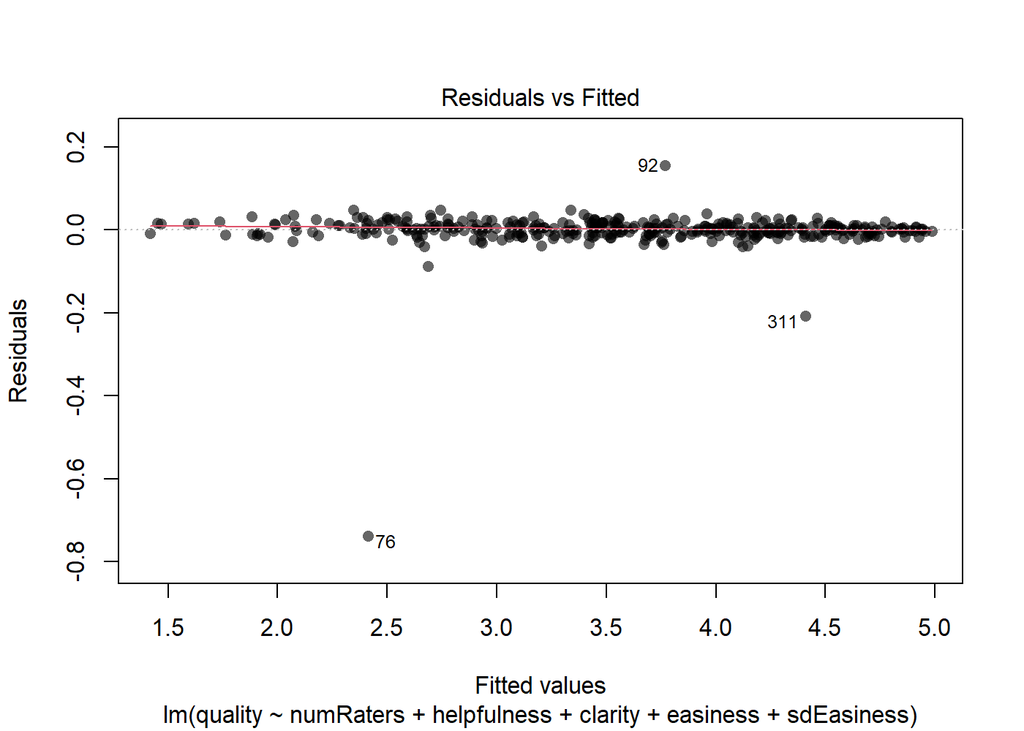

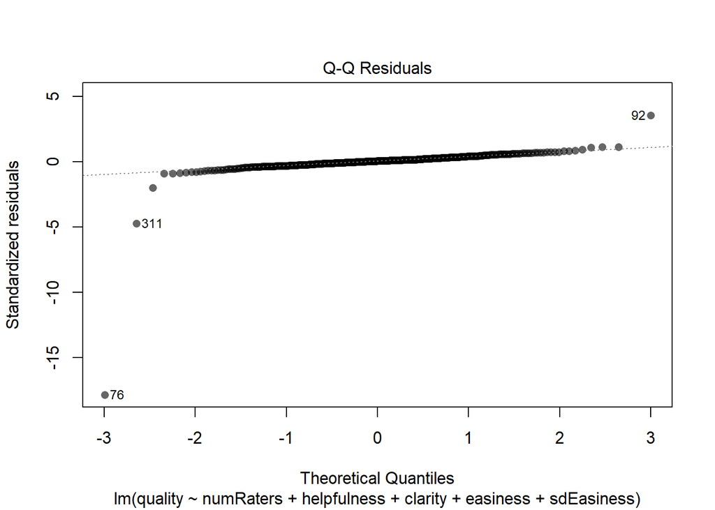

Diagnostic Plots for the Stepwise Additive Model II

### Fit the model: Interactions model

Remove helpfulness and clarity due to potential strong linear relationship between the two predictors and the response variable quality assessed by the pairs plot.

```r
#Interactions model introduced
#Full model -helpfulness, -clarity

lm3 <- lm(quality ~  discipline + dept +
      (gender + pepper + easiness +
      raterInterest + numYears + numCourses
      + numRaters + sdHelpfulness + sdClarity +
      sdEasiness + sdRaterInterest)^2, Rateprof)
```

Summary output for the interactions model.

```r
#Model III Summary Statistics
create_model_summary(lm3, "Regression Statistics: Stepwise Interactions Model III")
```

|  | Value | DF | Pr(>\|t\|) |
| --- | --- | --- | --- |
| F - Statistic | 7.2882 | 112 and 252 | < 2.2e-16 |
| Residual Standard Error | 0.4879 | 252 |  |
| Multiple R - Squared | 0.7657 |  |  |
| Adjusted R - Squared | 0.6606 |  |  |

### Check Assumptions

Constant Variance and Normality

A residuals versus fitted values plot with Breusch - Pagan test. And a normal Q - Q plot with Shapiro - Wilk test.

```r
#Residuals vs Fitted
plot(lm3, which = 1, col = rgb(0, 0, 0, 0.6), pch = 16)

#Normal Q-Q Plot
plot(lm3, which = 2, col = rgb(0, 0, 0, 0.6), pch = 16)

save.image()

#Breusch- Pagan Test
bp3 <- bptest(lm3)
bp3
```

```
##
##  studentized Breusch-Pagan test
##
## data:  lm3
## BP = 118.95, df = 113, p-value = 0.3325
```

```r
#Shapiro - Wilk Test
shap3 <- shapiro.test(resid(lm3))
shap3
```

```
##
##  Shapiro-Wilk normality test
##
## data:  resid(lm3)
## W = 0.9865, p-value = 0.001737
```

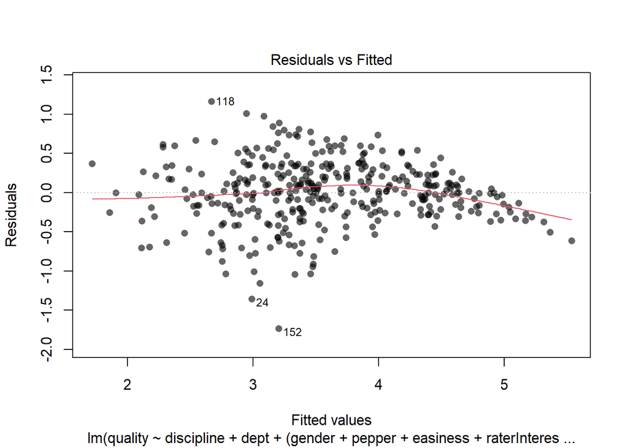

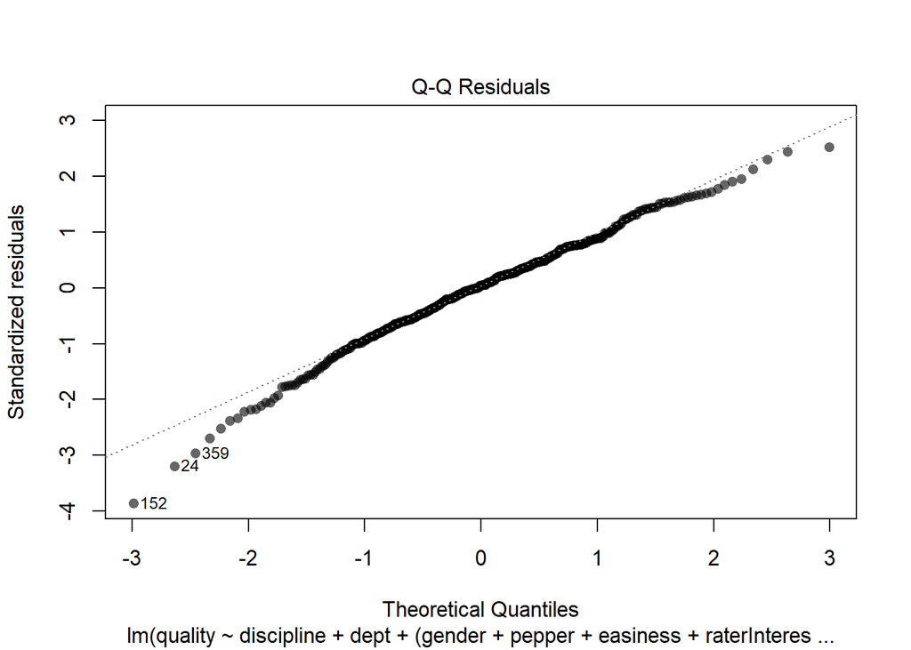

### Transformed Model

The assumptions are still violated, therefore check for transformations.

```r
#Try transformation with interaction model
summary(powerTransform(lm3))
```

```
## bcPower Transformation to Normality
##    Est Power Rounded Pwr Wald Lwr Bnd Wald Upr Bnd
## Y1    3.5598        3.56       3.0671       4.0525
##
## Likelihood ratio test that transformation parameter is equal to 0
##  (log transformation)
##                            LRT df       pval
## LR test, lambda = (0) 241.7316  1 < 2.22e-16
##
## Likelihood ratio test that no transformation is needed
##                            LRT df       pval
## LR test, lambda = (1) 117.9941  1 < 2.22e-16
```

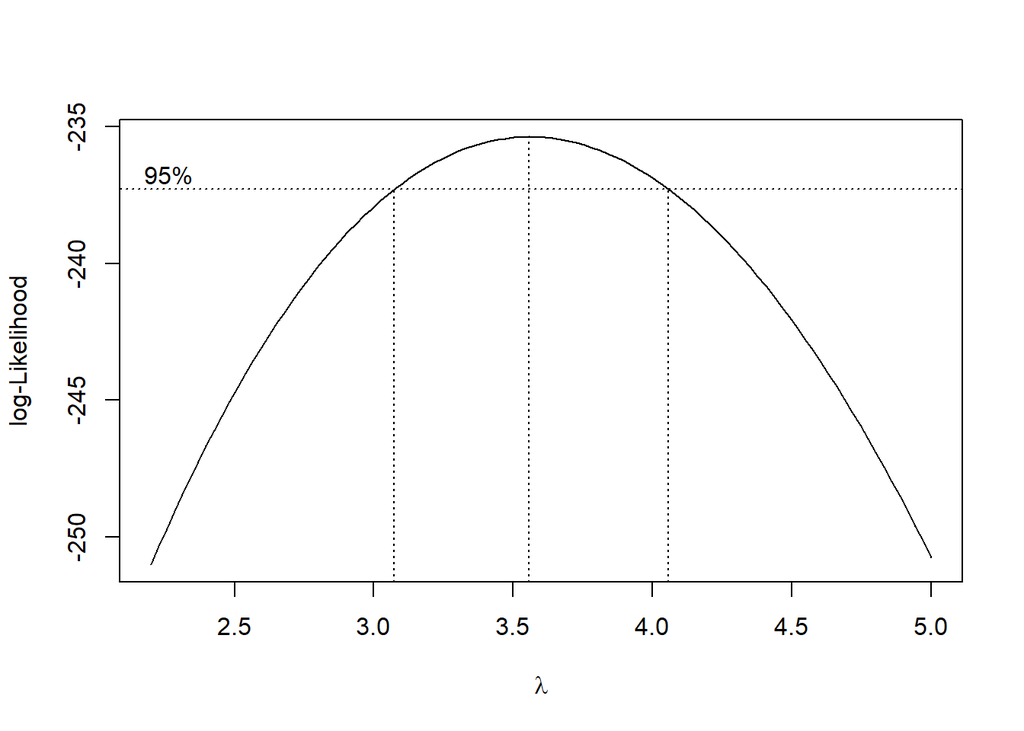

```r
boxcox(lm3, lambda = seq(2.2, 5.0, by = 0.05))
```

# Results

Final Model: Stepwise Transformed model

Model has been transformed and the stepwise function has been applied to the transformed model.

```r
#Transformed model
lm4 <- lm((quality^3.55) ~  discipline + dept +
    (gender + pepper + easiness +  raterInterest
    + numYears + numCourses  + numRaters + sdQuality
    + sdHelpfulness + sdClarity + sdEasiness
    + sdRaterInterest)^2, Rateprof)

#Apply step function
lm5 <- step(lm4, trace = 0)
```

Summary output for final model.

```r
#Tidy the model coefficients dynamically
tidy_coef <- tidy(lm5) |>
  mutate(
    across(where(is.numeric), ~ round(., 4)),
    # Add standard scientific significance indicator strings
    Significance = case_when(
      p.value < 0.001 ~ "***",
      p.value < 0.01  ~ "**",
      p.value < 0.05  ~ "*",
      p.value < 0.1   ~ ".",
      TRUE            ~ ""
    )
  )

#Build a beautiful, structured table
kable(
  tidy_coef,
  col.names = c("Predictor", "Estimate", "Std. Error", "t statistic", "Pr(>|t|)", ""),
  caption = "Regression Coefficients: Interactions Model IV",
  format = "html"  # Changed to HTML
) |>
  kable_styling(
    bootstrap_options = c("striped", "hover", "condensed"),
    full_width = TRUE
  ) |>
  row_spec(which(tidy_coef$p.value < 0.05), bold = TRUE, background = "#f9f9f9") %>%
  pack_rows("Main Effects", 1, 13) |>
  pack_rows("Interaction Terms", 14, nrow(tidy_coef))
```

Regression Coefficients: Interactions Model IV

Predictor

Estimate

Std. Error

t statistic

Pr(>|t|)

**Main Effects**

(Intercept)

-635.4418

142.0092

-4.4747

0.0000

***

gendermale

1.9668

13.3157

0.1477

0.8827

pepperyes

273.6179

84.0483

3.2555

0.0012

easiness

133.1880

23.9593

5.5589

0.0000

***

raterInterest

160.7527

26.0077

6.1810

0.0000

***

numYears

11.1823

4.9196

2.2730

0.0237

numCourses

-29.7393

11.0907

-2.6815

0.0077

numRaters

4.1821

0.9204

4.5438

0.0000

***

sdQuality

696.7181

143.1248

4.8679

0.0000

***

sdHelpfulness

-313.9197

121.2182

-2.5897

0.0100

sdClarity

-107.6537

93.1659

-1.1555

0.2487

sdEasiness

91.5367

40.0222

2.2872

0.0228

sdRaterInterest

57.6566

35.9237

1.6050

0.1095

**Interaction Terms**

gendermale:sdQuality

-71.4537

38.2115

-1.8700

0.0624

.

gendermale:sdClarity

70.5870

39.7194

1.7771

0.0765

.

pepperyes:raterInterest

-55.8436

16.5366

-3.3770

0.0008

***

pepperyes:sdQuality

-80.3646

49.4553

-1.6250

0.1051

pepperyes:sdClarity

104.6555

54.3565

1.9254

0.0550

.

pepperyes:sdRaterInterest

-63.1330

28.0364

-2.2518

0.0250

easiness:raterInterest

-22.1231

4.9690

-4.4522

0.0000

***

easiness:numCourses

2.5403

1.3805

1.8402

0.0666

.

easiness:numRaters

-0.4260

0.1595

-2.6705

0.0079

easiness:sdClarity

-31.9363

10.5086

-3.0390

0.0026

raterInterest:numYears

-2.1359

1.1757

-1.8167

0.0702

.

raterInterest:numCourses

4.1844

2.0977

1.9948

0.0469

raterInterest:sdQuality

-135.5478

32.1890

-4.2110

0.0000

***

raterInterest:sdHelpfulness

73.1120

29.2719

2.4977

0.0130

numYears:sdClarity

-2.8640

2.0005

-1.4316

0.1532

numCourses:numRaters

-0.1073

0.0590

-1.8186

0.0699

.

numCourses:sdQuality

36.3869

10.7742

3.3772

0.0008

***

numCourses:sdHelpfulness

-24.1331

9.5501

-2.5270

0.0120

numRaters:sdQuality

-2.1956

0.4974

-4.4142

0.0000

***

sdQuality:sdHelpfulness

-91.9033

51.8711

-1.7718

0.0774

.

sdHelpfulness:sdClarity

119.6386

59.5297

2.0097

0.0453

sdHelpfulness:sdRaterInterest

-48.0130

27.3997

-1.7523

0.0806

.

sdClarity:sdEasiness

-73.5619

33.3979

-2.2026

0.0283

```r
#Model IV Summary Statistics
create_model_summary(lm5, "Regression Statistics: Transformed Model IV")
```

Regression Statistics: Transformed Model IV

|  | Value | DF | Pr(>\|t\|) |
| --- | --- | --- | --- |
| F - Statistic | 48.2083 | 34 and 330 | < 2.2e-16 |
| Residual Standard Error | 33.2921 | 330 |  |
| Multiple R - Squared | 0.8364 |  |  |
| Adjusted R - Squared | 0.8191 |  |  |

### Check Assumptions

Constant Variance and Normality

A residuals versus fitted values plot with Breusch - Pagan test. And a normal Q - Q plot with Shapiro - Wilk test.

```r
#Residuals vs Fitted
plot(lm5, which = 1, col = rgb(0, 0, 0, 0.6), pch = 16)

#Normal Q-Q Plot
plot(lm5, which = 2, col = rgb(0, 0, 0, 0.6), pch = 16)

save.image()

#Breusch- Pagan Test
bp5 <- bptest(lm5)
bp5
```

```
##
##  studentized Breusch-Pagan test
##
## data:  lm5
## BP = 45.006, df = 35, p-value = 0.1198
```

```r
#Shapiro - Wilk Test
shap5 <- shapiro.test(resid(lm5))
shap5
```

```
##
##  Shapiro-Wilk normality test
##
## data:  resid(lm5)
## W = 0.994, p-value = 0.1586
```

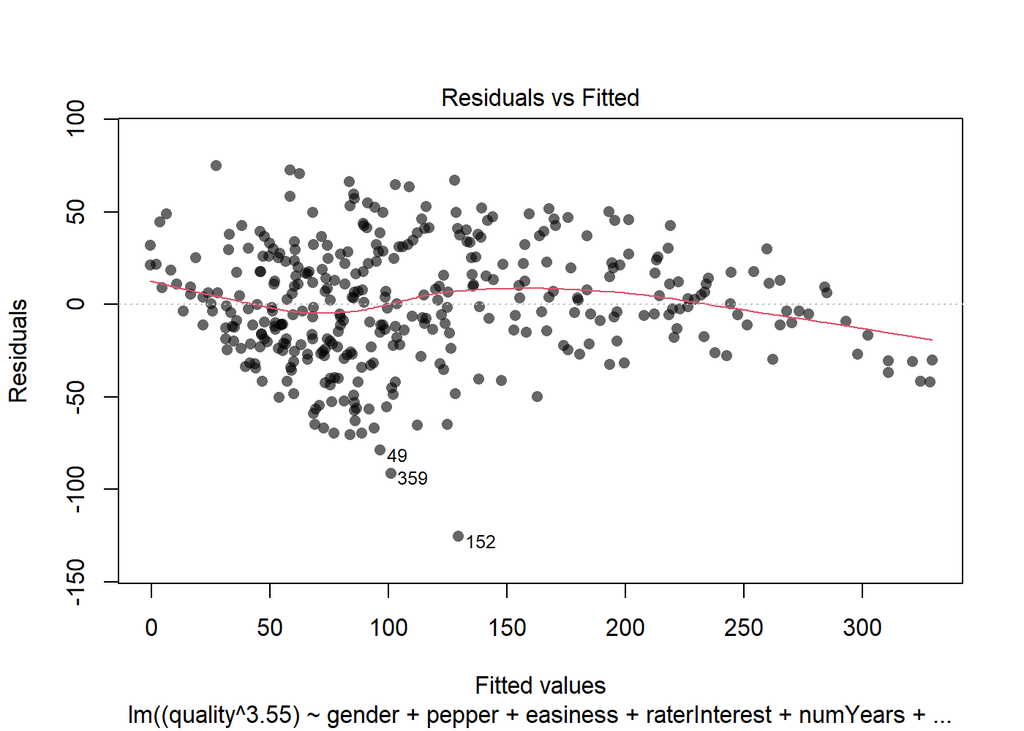

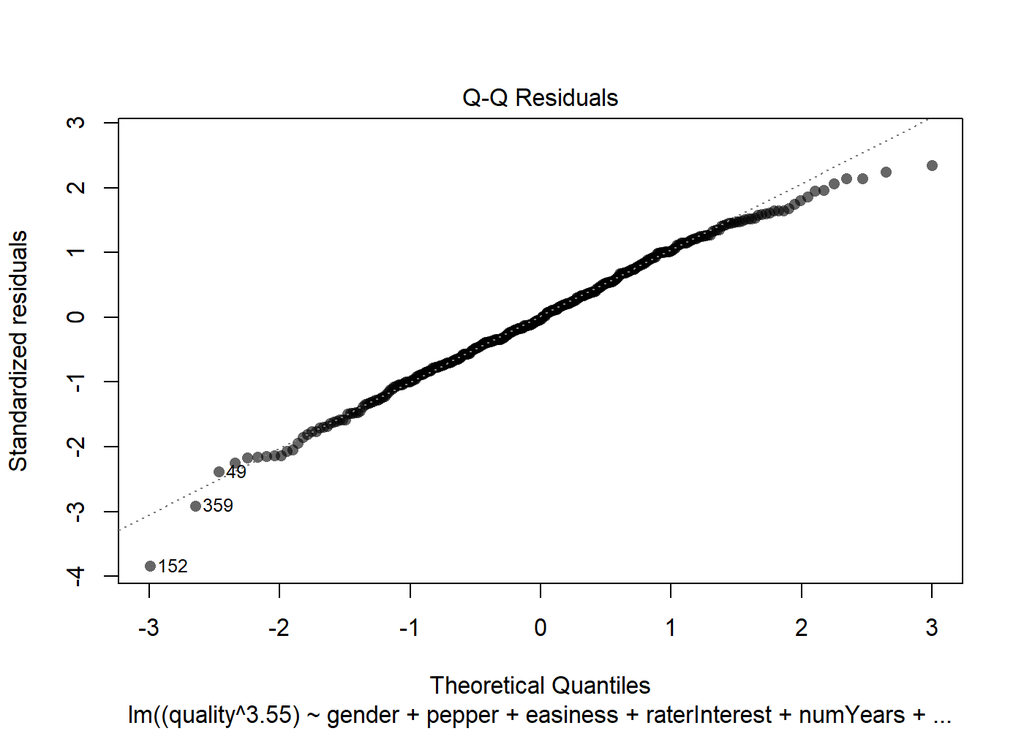

Diagnostic Plots for the Final Transformed Model IV

### Conclusions

To address multicollinearity and remove non-significant higher-order terms, stepwise AIC selection was performed on the transformed interaction model ($\text{Model IV}$). The resulting parsimonious model retains key main effects along with 23 moderating two-way interaction terms that best optimize predictive performance and model fit:

```r
#Final Model
# Display the final model selected by stepwise regression
formula(lm5)
```

```
## (quality^3.55) ~ gender + pepper + easiness + raterInterest +
##     numYears + numCourses + numRaters + sdQuality + sdHelpfulness +
##     sdClarity + sdEasiness + sdRaterInterest + gender:sdQuality +
##     gender:sdClarity + pepper:raterInterest + pepper:sdQuality +
##     pepper:sdClarity + pepper:sdRaterInterest + easiness:raterInterest +
##     easiness:numCourses + easiness:numRaters + easiness:sdClarity +
##     raterInterest:numYears + raterInterest:numCourses + raterInterest:sdQuality +
##     raterInterest:sdHelpfulness + numYears:sdClarity + numCourses:numRaters +
##     numCourses:sdQuality + numCourses:sdHelpfulness + numRaters:sdQuality +
##     sdQuality:sdHelpfulness + sdHelpfulness:sdClarity + sdHelpfulness:sdRaterInterest +
##     sdClarity:sdEasiness
```

### Table: Comparison of Models

The table includes: adjusted $R^2$, Shapiro - Wilk p - value, and Breusch - Pagan p - value.

The models: full additive model I, full stepwise model II, interactions model III, and final model IV.

```r
#Dynamically extract the p-values from your saved test objects
models_tb <- data.frame(
  "Model" = c("Full Additive I", "Full Step II", "Interactions III", "Final IV"),

  "Adj. $R^2$" = c(
    round(glance(lm1)$adj.r.squared, 4),
    round(glance(lm2)$adj.r.squared, 4),
    round(glance(lm3)$adj.r.squared, 4),
    round(glance(lm5)$adj.r.squared, 4)
  ),

  "Shapiro - Wilk" = c(
    format.pval(shap1$p.value, digits = 4),
    format.pval(shap2$p.value, digits = 4),
    format.pval(shap3$p.value, digits = 4),
    format.pval(shap5$p.value, digits = 4)
  ),

  "Breusch - Pagan" = c(
    format.pval(bp1$p.value, digits = 4),
    format.pval(bp2$p.value, digits = 4),
    format.pval(bp3$p.value, digits = 4),
    format.pval(bp5$p.value, digits = 4)
  ),

  check.names = FALSE
)

kable(
  models_tb,
  caption = "Regression Models Comparison",
  align = c("l", "c", "c", "c"),
  format = "html"  # Changed to HTML
) %>%
  kable_styling(
    bootstrap_options = c("striped", "hover", "condensed"),
    full_width = FALSE,
    position = "center"
  )
```

Regression Models Comparison

| Model | Adj. $R^2$ | Shapiro - Wilk | Breusch - Pagan |
| --- | --- | --- | --- |
| Full Additive I | 0.9968 | < 2.2e-16 | 0.3143 |
| Full Step II | 0.9972 | < 2.2e-16 | 1.421e-08 |
| Interactions III | 0.6606 | 0.001737 | 0.3325 |
| Final IV | 0.8191 | 0.1586 | 0.1198 |